# AWS Sentiment & Review Date/Time Part 1

Eugenie

07/08/2019

# 1 Load Source File

Data pre-processing is included, where special chars and minimal stop-words are removed.

```r
## load review data
source("~/Dropbox/Eugenie/scripts/utils.R")
```

Load AWS review sentiment data.

```r
aws_reviews <- read.csv("~/Dropbox/Eugenie/data/processed/aws-reviews2-all.csv")
```

# 2 Data Processing

Add category data as extra columns. Join on either item_id or child_id.

```r
reviews2.temp <- reviews2.csv
```

```r
reviews2.temp <- reviews2.temp[as.numeric(as.character(reviews2.temp$year))>2013,]
```

Drop records after 2018-10-07 since it’s not a full week.

```r
reviews2.temp <- reviews2.temp[reviews2.temp$date < '2018-10-07',]
```

Drop records with no product category.

```r
reviews2.temp <- reviews2.temp[reviews2.temp$product_cat != 'none',]
```

Get selected columns for further analysis.

```r
reviews.product <- merge(aws_reviews,reviews2.temp[,c('recid','item_id','incentivized','product_cat','rating','word_count','helpful_yes','date','year','month','week')])
```

# 3 Time Data vs. Positive Sentiment Probability

## 3.1 Data processing

Split data on date without splitting incentivized vs. non-incentivized reviews after 2016-10-03.

Compute positive sentiment stats without splitting incentivized vs. non-incentivized reviews after 2016-10-03.

## 3.2 Plot mean positive sentiment probability over time by product_cat without splitting incentivized vs. non-incentivized reviews after 2016-10-03

### 3.2.1 Positive sentiment probability average by day

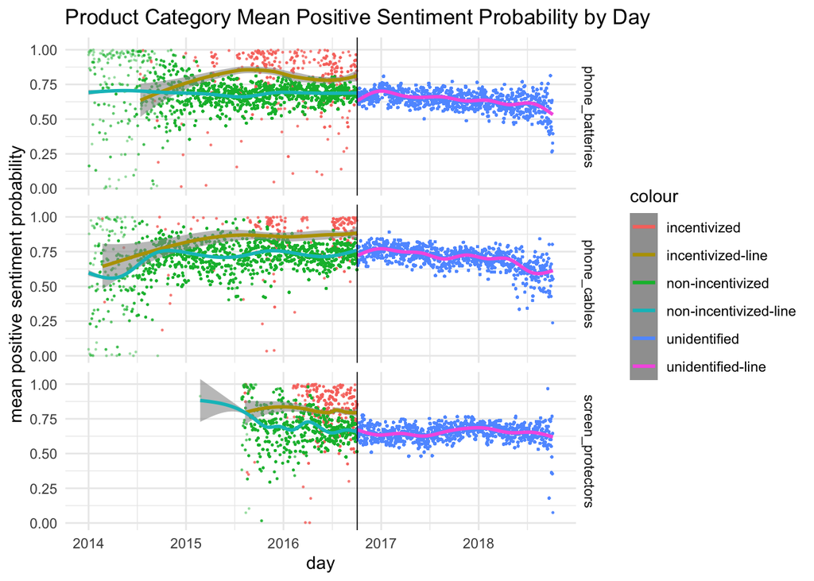

Observed that prior to 2016-10-03, the day average of incentivized reviews is generally higher and has a greater variation than non-incentivized reviews.

### 3.2.2 Positive sentiment probability averaged by week

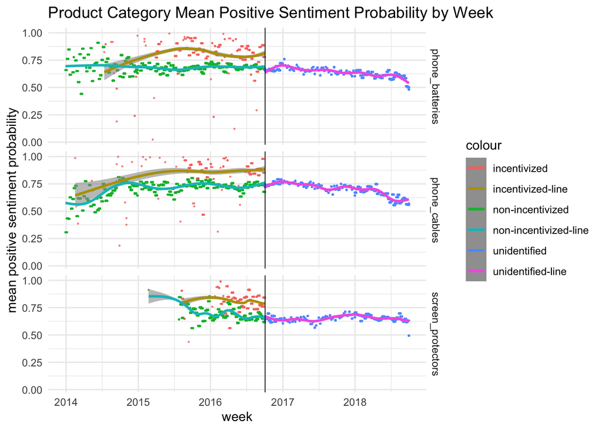

### 3.2.3 Positive sentiment probability averaged by month

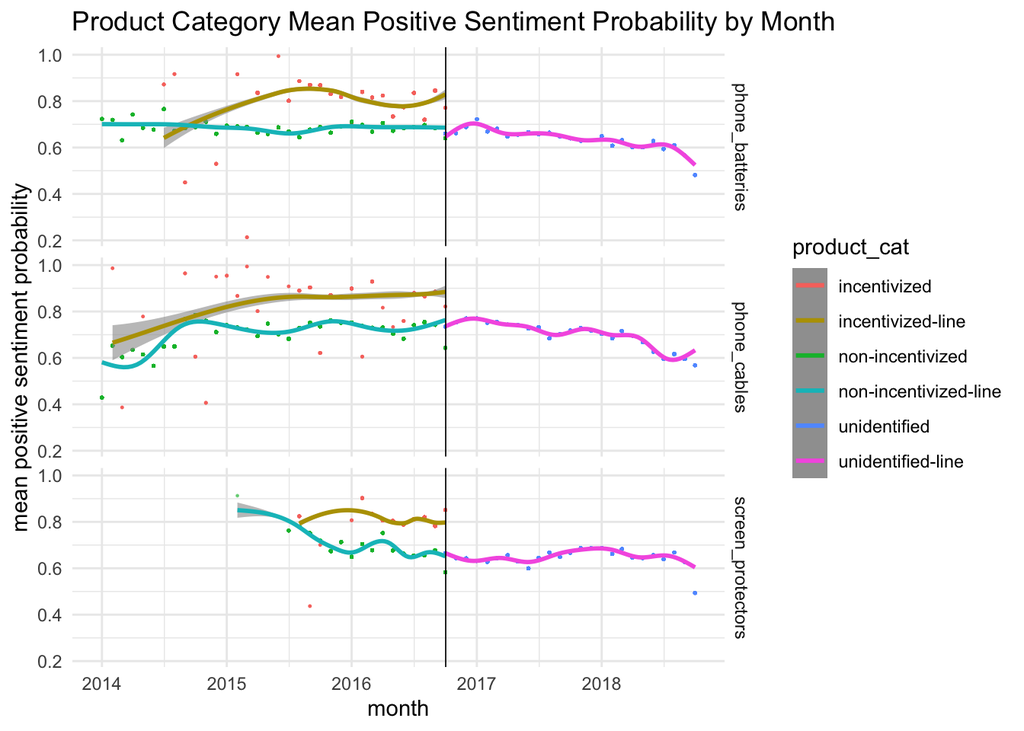

# 4 Time Data vs. Neutral Sentiment Probability

## 4.1 Data processing

Compute neutral sentiment stats without splitting incentivized vs. non-incentivized reviews after 2016-10-03.

## 4.2 Plot mean neutral sentiment probability over time by product_cat without splitting incentivized vs. non-incentivized reviews after 2016-10-03

### 4.2.1 Neutral sentiment probability average by day

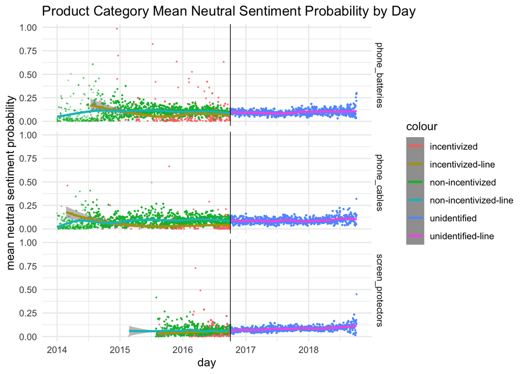

### 4.2.2 Neutral sentiment probability averaged by week

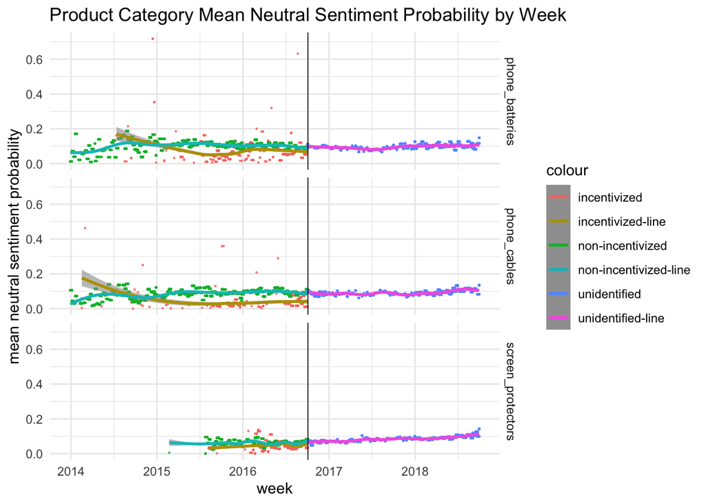

### 4.2.3 Neutral sentiment probability averaged by month

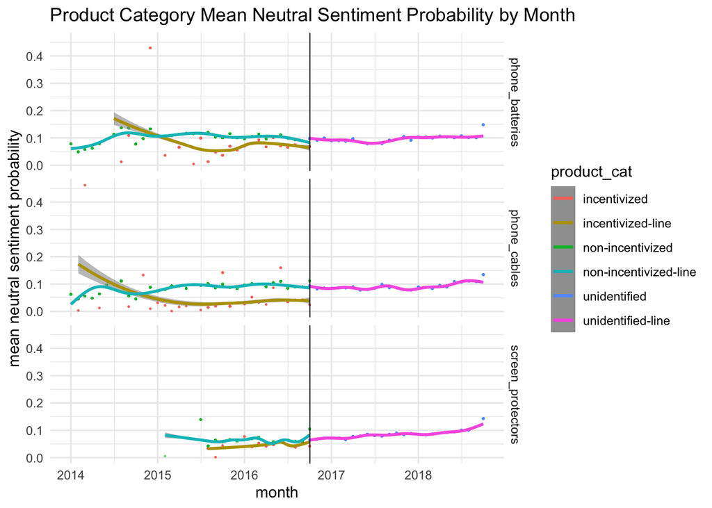